# Polysome RBPs

This document details the analysis of proteomics data acquired for comparison of RBPs in polysomes.

## Setting up the environment

```r
##########################################################################################
library('tidyverse')
library('RColorBrewer')
library('ggplot2')
library('ggrepel')
library('matrixStats')
library('DEqMS')
```

I want to set a base directory that we can use as a link to the directory where we will do most of the work. I use two directories here because the Workspace is what is pushed to GitHub and contains scripts and plot files, but the Repository is where more of the big data is stored that does not get pushed.

```r
##########################################################################################
generalDatasets = 'C:/Users/chughes/Documents/bccrc/projectsRepository/generalDatasets'
baseWorkspace = 'C:/Users/chughes/Documents/bccrc/projectsWorkspace/sorensenLab/relatedToYbx1'
baseRepository = 'C:/Users/chughes/Documents/bccrc/projectsRepository/sorensenLab/relatedToYbx1'
#generalDatasets = 'C:/Users/chris/OneDrive/Documents/bccrc/projectsRepository/generalDatasets'
#baseWorkspace = 'C:/Users/chris/OneDrive/Documents/bccrc/projectsWorkspace/sorensenLab/relatedToYbx1'
#baseRepository = 'C:/Users/chris/OneDrive/Documents/bccrc/projectsRepository/sorensenLab/relatedToYbx1'
```

## Data processing

```r
##########################################################################################
samples = tibble('sampleName' = paste('polyRbp_',seq(1,3,1),sep=''),
                 'samplePrefix' = 'polyRbp')

##
peptideFiles = file.path(baseRepository, 'proteomics20210324_hek293PolysomeRbpsSearchOutput', samples$sampleName, 'ion_label_quant.tsv')
all(file.exists(peptideFiles))
```

```
[1] TRUE
```

```r
##
peptideSet = data.frame()
for (i in 1:length(peptideFiles)){
  tempPeptides = read_tsv(peptideFiles[i]) %>%
    dplyr::select(`Protein ID`, `Gene`, `Peptide Sequence`, `Light Intensity`, `Heavy Intensity`) %>%
    dplyr::rename(accession = `Protein ID`, symbol = `Gene`, sequence = `Peptide Sequence`,
                  noCL = `Light Intensity`,
                  CL = `Heavy Intensity`) %>%
    dplyr::mutate(dataset = samples[i,'sampleName']$sampleName) %>%
    dplyr::filter(noCL > 0 | CL > 0)
  ##
  peptideSet = rbind(peptideSet, tempPeptides)
}
saveRDS(peptideSet,
        paste(baseRepository, '/proteomics20210324_hek293PolysomeRbpsSearchOutput/dataset_allPeptideData.rds', sep = ''))
```

Now work the peptide set through deqms.

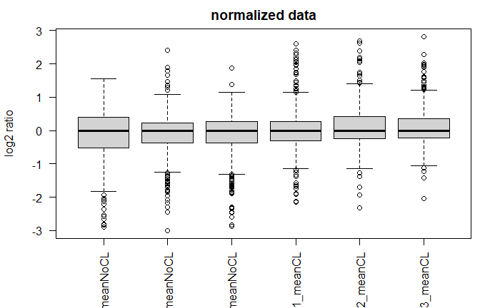

```r
##########################################################################################
pep = readRDS(paste(baseRepository, '/proteomics20210324_hek293PolysomeRbpsSearchOutput/dataset_allPeptideData.rds', sep = '')) %>%
  dplyr::select(sequence, symbol, noCL, CL, dataset) %>%
  dplyr::group_by(sequence, symbol, dataset) %>%
  dplyr::summarise(meanNoCL = mean(noCL, na.rm = TRUE), meanCL = mean(CL, na.rm = TRUE)) %>%
  pivot_longer(cols = meanNoCL:meanCL, names_to = 'treatment', values_to = 'intensity') %>%
  pivot_wider(names_from = c(dataset, treatment), values_from = intensity) %>%
  dplyr::select(sequence, symbol, c(3,5,7,4,6,8)) %>%
  dplyr::filter(!is.na(symbol))

##
pepSub = subset(pep, rowSums(is.na(pep[,3:8])) < 3)
pepSub[,3:8] = log2(pepSub[,3:8])
pepSubNorm = medianSweeping(pepSub, group_col = 2)
boxplot(pepSubNorm, las=2, ylab='log2 ratio', main='normalized data')
```

```r
##
geneMatrix = as.matrix(pepSubNorm)
cond = as.factor(rep(c('noCL','CL'), each = 3))
design = model.matrix(~0+cond)
colnames(design) = gsub('cond', '', colnames(design))
fit1 = lmFit(geneMatrix, design)
forContrast = c('noCL-CL')
contrast =  makeContrasts(contrasts = forContrast, levels = design)
fit2 = eBayes(contrasts.fit(fit1, contrasts = contrast))
psmCountTable = as.data.frame(table(pepSub$symbol))
rownames(psmCountTable) = psmCountTable$Var1

fit2$count = psmCountTable[rownames(fit2$coefficients),2]
fit3 = spectraCounteBayes(fit2)
deqmsResults = outputResult(fit3,coef_col = 1)
head(deqmsResults)
```

|  | logFC | AveExpr | t | P.Value | adj.P.Val | B | gene | count | sca.t | sca.P.Value | sca.adj.pval |
| --- | --- | --- | --- | --- | --- | --- | --- | --- | --- | --- | --- |
| HNRNPC | -3.635746 | 0.03377522 | -23.04165 | 1.821316e-07 | 4.178858e-05 | 8.149622 | HNRNPC | 11 | -27.84243 | 1.980058e-08 | 5.778079e-06 |
| CSDE1 | -4.425638 | -0.03498137 | -24.01878 | 1.395072e-07 | 4.178858e-05 | 8.382610 | CSDE1 | 15 | -27.65582 | 2.074714e-08 | 5.778079e-06 |
| FUBP3 | -4.432123 | -0.07719063 | -22.29361 | 2.250732e-07 | 4.178858e-05 | 7.961411 | FUBP3 | 7 | -24.38810 | 4.962703e-08 | 9.214085e-06 |
| ELAVL1 | -4.485652 | -0.11679364 | -20.45080 | 3.911407e-07 | 5.446634e-05 | 7.457448 | ELAVL1 | 8 | -22.45635 | 8.785625e-08 | 1.223398e-05 |
| RPS2 | -3.326369 | -0.05388242 | -18.48377 | 7.463388e-07 | 8.314215e-05 | 6.847039 | RPS2 | 10 | -21.38787 | 1.230495e-07 | 1.367021e-05 |
| SYNCRIP | -3.071691 | 0.02632530 | -17.75906 | 9.630986e-07 | 8.940765e-05 | 6.600450 | SYNCRIP | 14 | -20.83870 | 1.472554e-07 | 1.367021e-05 |

Plot some of the results.

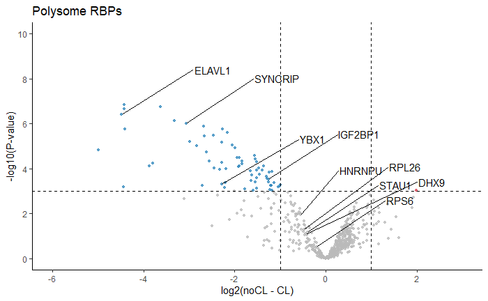

```r
##########################################################################################
plotData = as.data.frame(deqmsResults)
write.table(plotData, paste(baseRepository, '/proteomics20210324_hek293PolysomeRbpsSearchOutput/dataset_deqmsAnalysis_noCL-CL.tsv', sep = ''),
            col.names = TRUE, row.names = FALSE, quote = FALSE, sep = '\t')
plotData$logPValue = -log10(plotData$P.Value)
plotData$logPValueScaled = ifelse(plotData$logPValue > 10, 10, plotData$logPValue)
plotData$logFCScaled = ifelse(plotData$logFC > 6, 6, plotData$logFC)
plotData$logFCScaled = ifelse(plotData$logFC < -6, -6, plotData$logFC)
plotData$pColors = ifelse(plotData$P.Value <= 0.001 & plotData$logFC >= 1, brewer.pal(8,'Spectral')[1],
                        ifelse(plotData$P.Value <= 0.001 & plotData$logFC <= -1, brewer.pal(8,'Spectral')[8], brewer.pal(11,'RdGy')[8]))
goi = c('YBX1','RPL26','IGF2BP1','ELAVL1','DHX9','SYNCRIP','RPS6','STAU1','HNRNPU')
plotData$pText = ifelse(plotData$gene %in% goi, plotData$gene, '')
##
ggplot(plotData, aes(logFCScaled, logPValueScaled)) +
  geom_point(size = 1, color = plotData$pColors, alpha = 0.75) +
  labs(x = 'log2(noCL - CL)', y = '-log10(P-value)', title = 'Polysome RBPs') +
  geom_text_repel(label = plotData$pText, nudge_x = 2, nudge_y = 2) +
  scale_x_continuous(limits = c(-6,3), breaks = seq(-10,10,2)) +
  scale_y_continuous(limits = c(0,10), breaks = seq(0,10,2)) +
  geom_vline(xintercept = c(-1,1), linetype = 'dashed') +
  geom_hline(yintercept = -log10(0.001), linetype = 'dashed') +
  theme_classic()
##
ggsave(paste(baseRepository, '/proteomics20210324_hek293PolysomeRbpsSearchOutput/scatter_deqmsAnalysis_noCL-CL.pdf', sep = ''),
      height = 4, width = 4, useDingbats = FALSE)
```

Process the membrane polysome data just as above.

```r
##########################################################################################
samplePrefix = c('memEdta','memTime0','memTime30','memTime60','memTime120','memTime240')
samples = tibble('sampleName' = paste(rep(samplePrefix,each=3),'_',seq(1,3,1),sep=''),
                 'samplePrefix' = rep(samplePrefix, each=3),
                 'treatment' = c(rep('edta',3),rep('dmso',3),rep('arsenite',12)))

##
peptideFiles = file.path(baseRepository, 'proteomics20210309_hek293ArseniteTimecourseSearchOutput/fraction3', samples$sampleName, 'peptide_label_quant.tsv')
all(file.exists(peptideFiles))
```

```
[1] TRUE
```

```r
##
peptideSet = data.frame()
for (i in 1:length(peptideFiles)){
  tempPeptides = read_tsv(peptideFiles[i]) %>%
    dplyr::select(`Protein ID`, `Gene`, `Peptide Sequence`, `Light Intensity`, `Heavy Intensity`) %>%
    dplyr::rename(accession = `Protein ID`, symbol = `Gene`, sequence = `Peptide Sequence`,
                  light = `Light Intensity`,
                  heavy = `Heavy Intensity`) %>%
    dplyr::mutate(dataset = samples[i,'sampleName']$sampleName) %>%
    dplyr::filter(light > 0 | heavy > 0)
  ##
  peptideSet = rbind(peptideSet, tempPeptides)
}
saveRDS(peptideSet,
        paste(baseRepository, '/proteomics20210309_hek293ArseniteTimecourseSearchOutput/fraction3/dataset_allPeptideDataMembrane.rds', sep = ''))
```

Now work the peptide set through deqms.

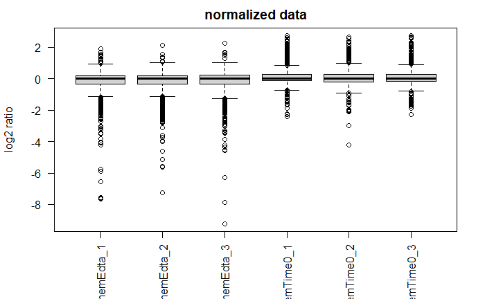

```r
##########################################################################################
pep = readRDS(paste(baseRepository, '/proteomics20210309_hek293ArseniteTimecourseSearchOutput/fraction3/dataset_allPeptideDataMembrane.rds', sep = '')) %>%
  dplyr::select(sequence, symbol, light, dataset) %>%
  dplyr::group_by(sequence, symbol, dataset) %>%
  dplyr::summarise(mean = mean(light, na.rm = TRUE)) %>%
  pivot_wider(names_from = dataset, values_from = mean) %>%
  dplyr::select(sequence, symbol, samples$sampleName[c(1:3,4:6)]) %>%
  dplyr::filter(!is.na(symbol))

##
pepSub = subset(pep, rowSums(is.na(pep[,3:8])) < 3)
pepSub[,3:8] = log2(pepSub[,3:8])
pepSubNorm = medianSweeping(pepSub, group_col = 2)
boxplot(pepSubNorm, las=2, ylab='log2 ratio', main='normalized data')
```

```r
##
geneMatrix = as.matrix(pepSubNorm)
cond = as.factor(rep(c('edta','time0'), each = 3))
design = model.matrix(~0+cond)
colnames(design) = gsub('cond', '', colnames(design))
fit1 = lmFit(geneMatrix, design)
forContrast = c('edta-time0')
contrast =  makeContrasts(contrasts = forContrast, levels = design)
fit2 = eBayes(contrasts.fit(fit1, contrasts = contrast))
psmCountTable = as.data.frame(table(pepSub$symbol))
rownames(psmCountTable) = psmCountTable$Var1

fit2$count = psmCountTable[rownames(fit2$coefficients),2]
fit3 = spectraCounteBayes(fit2)
deqmsResults = outputResult(fit3,coef_col = 1)
head(deqmsResults)
```

|  | logFC | AveExpr | t | P.Value | adj.P.Val | B | gene | count | sca.t | sca.P.Value | sca.adj.pval |
| --- | --- | --- | --- | --- | --- | --- | --- | --- | --- | --- | --- |
| RPS16 | -4.455177 | -0.31659512 | -65.92748 | 1.979207e-10 | 8.696099e-08 | 14.71083 | RPS16 | 8 | -75.70614 | 4.325793e-12 | 3.880237e-09 |
| RPS3A | -4.837942 | -0.09059755 | -57.57083 | 4.769337e-10 | 8.696099e-08 | 13.99715 | RPS3A | 11 | -68.44666 | 9.204107e-12 | 3.991029e-09 |
| RPL13 | -4.275361 | -0.07194286 | -57.42707 | 4.847324e-10 | 8.696099e-08 | 13.98346 | RPL13 | 8 | -65.13218 | 1.334792e-11 | 3.991029e-09 |
| RPL17 | -3.664493 | -0.09256867 | -47.85601 | 1.581253e-09 | 1.289440e-07 | 12.93915 | RPL17 | 8 | -54.10750 | 5.349282e-11 | 9.344370e-09 |
| RPL23A | -4.431355 | -0.18549334 | -48.25123 | 1.499153e-09 | 1.289440e-07 | 12.98810 | RPL23A | 7 | -52.37276 | 6.826289e-11 | 9.344370e-09 |
| RPS2 | -3.417424 | -0.06284164 | -44.40571 | 2.568198e-09 | 1.645481e-07 | 12.48665 | RPS2 | 9 | -51.65601 | 7.567605e-11 | 9.344370e-09 |

Plot some of the results.

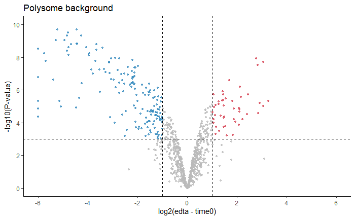

```r
##########################################################################################
plotData = as.data.frame(deqmsResults)
write.table(plotData, paste(baseRepository, '/proteomics20210309_hek293ArseniteTimecourseSearchOutput/fraction3/dataset_deqmsAnalysisMembrane_edta-time0.tsv', sep = ''),
            col.names = TRUE, row.names = FALSE, quote = FALSE, sep = '\t')
plotData$logPValue = -log10(plotData$P.Value)
plotData$logPValueScaled = ifelse(plotData$logPValue > 10, 10, plotData$logPValue)
plotData$logFCScaled = ifelse(plotData$logFC > 6, 6, plotData$logFC)
plotData$logFCScaled = ifelse(plotData$logFC < -6, -6, plotData$logFC)
plotData$pColors = ifelse(plotData$P.Value <= 0.001 & plotData$logFC >= 1, brewer.pal(8,'Spectral')[1],
                        ifelse(plotData$P.Value <= 0.001 & plotData$logFC <= -1, brewer.pal(8,'Spectral')[8], brewer.pal(11,'RdGy')[8]))
plotData$pText = ifelse(grepl('YBX1',plotData$gene), plotData$gene, '')
##
ggplot(plotData, aes(logFCScaled, logPValueScaled)) +
  geom_point(size = 1, color = plotData$pColors, alpha = 0.75) +
  labs(x = 'log2(edta - time0)', y = '-log10(P-value)', title = 'Polysome background') +
  geom_text_repel(label = plotData$pText, nudge_x = 2, nudge_y = -1) +
  scale_x_continuous(limits = c(-6,6), breaks = seq(-10,10,2)) +
  scale_y_continuous(limits = c(0,10), breaks = seq(0,10,2)) +
  geom_vline(xintercept = c(-1,1), linetype = 'dashed') +
  geom_hline(yintercept = -log10(0.001), linetype = 'dashed') +
  theme_classic()
##
ggsave(paste(baseRepository, '/proteomics20210309_hek293ArseniteTimecourseSearchOutput/fraction3/scatter_deqmsAnalysisMembrane_edta-time0.pdf', sep = ''),
      height = 4, width = 4, useDingbats = FALSE)
```

Now do it for one of the arsenite samples.

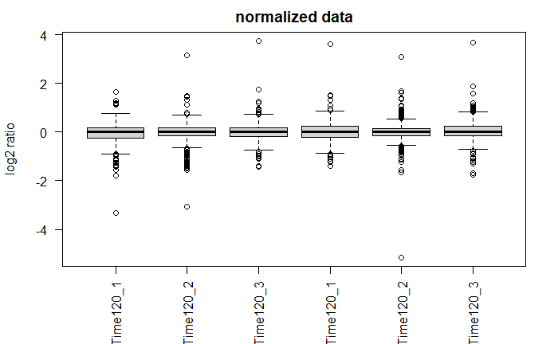

```r
##########################################################################################
pep = readRDS(paste(baseRepository, '/proteomics20210309_hek293ArseniteTimecourseSearchOutput/fraction3/dataset_allPeptideData.rds', sep = '')) %>%
  dplyr::select(sequence, symbol, light, heavy, dataset) %>%
  dplyr::group_by(sequence, symbol, dataset) %>%
  dplyr::summarise(mean_light = mean(light, na.rm = TRUE), mean_heavy = mean(heavy, na.rm = TRUE)) %>%
  dplyr::filter(grepl('cytoTime120',dataset)) %>%
  pivot_wider(names_from = dataset, values_from = mean_light:mean_heavy) %>%
  dplyr::filter(!is.na(symbol))

##
pepSub = subset(pep, rowSums(is.na(pep[,3:8])) < 3)
pepSub[,3:8] = log2(pepSub[,3:8])
pepSubNorm = medianSweeping(pepSub, group_col = 2)
boxplot(pepSubNorm, las=2, ylab='log2 ratio', main='normalized data')
```

```r
##
geneMatrix = as.matrix(pepSubNorm)
cond = as.factor(rep(c('time120dmso','time120arsenite'), each = 3))
design = model.matrix(~0+cond)
colnames(design) = gsub('cond', '', colnames(design))
fit1 = lmFit(geneMatrix, design)
forContrast = c('time120dmso-time120arsenite')
contrast =  makeContrasts(contrasts = forContrast, levels = design)
fit2 = eBayes(contrasts.fit(fit1, contrasts = contrast))
psmCountTable = as.data.frame(table(pepSub$symbol))
rownames(psmCountTable) = psmCountTable$Var1

fit2$count = psmCountTable[rownames(fit2$coefficients),2]
fit3 = spectraCounteBayes(fit2)
deqmsResults = outputResult(fit3,coef_col = 1)
head(deqmsResults)
```

|  | logFC | AveExpr | t | P.Value | adj.P.Val | B | gene | count | sca.t | sca.P.Value | sca.adj.pval |
| --- | --- | --- | --- | --- | --- | --- | --- | --- | --- | --- | --- |
| VPS35 | -3.115621 | 0.13160739 | -26.93672 | 5.782113e-08 | 1.780891e-05 | 9.377550 | VPS35 | 1 | -18.57511 | 4.075599e-08 | 1.333345e-05 |
| NAA40 | -2.921420 | 0.01921243 | -29.97992 | 2.879498e-08 | 1.773771e-05 | 10.030019 | NAA40 | 1 | -18.43925 | 4.329042e-08 | 1.333345e-05 |
| DDX5 | -2.292462 | 0.02120875 | -18.18882 | 7.369563e-07 | 1.134913e-04 | 6.815470 | DDX5 | 2 | -15.28986 | 2.002971e-07 | 3.300212e-05 |
| HCFC1 | -6.555732 | 0.07913932 | -29.47003 | 2.220908e-06 | 2.280132e-04 | 5.890304 | HCFC1 | 1 | -22.30752 | 2.606111e-07 | 3.300212e-05 |
| CD151 | 2.454349 | 0.05605061 | 21.69795 | 2.355868e-07 | 4.837383e-05 | 7.993203 | CD151 | 1 | 14.75259 | 2.678744e-07 | 3.300212e-05 |
| POP1 | 1.951919 | 0.04860448 | 12.90422 | 6.628730e-06 | 5.833283e-04 | 4.455963 | POP1 | 5 | 13.84454 | 4.481278e-07 | 4.600779e-05 |

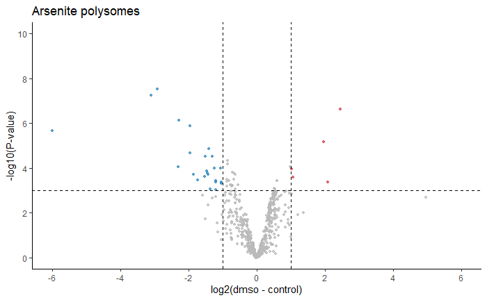

```r
##
plotData = as.data.frame(deqmsResults)
write.table(plotData, paste(baseRepository, '/proteomics20210309_hek293ArseniteTimecourseSearchOutput/fraction3/dataset_deqmsAnalysis_time120dmso-arsenite.tsv', sep = ''),
            col.names = TRUE, row.names = FALSE, quote = FALSE, sep = '\t')
plotData$logPValue = -log10(plotData$P.Value)
plotData$logPValueScaled = ifelse(plotData$logPValue > 10, 10, plotData$logPValue)
plotData$logFCScaled = ifelse(plotData$logFC > 6, 6, plotData$logFC)
plotData$logFCScaled = ifelse(plotData$logFC < -6, -6, plotData$logFC)
plotData$pColors = ifelse(plotData$P.Value <= 0.001 & plotData$logFC >= 1, brewer.pal(8,'Spectral')[1],
                        ifelse(plotData$P.Value <= 0.001 & plotData$logFC <= -1, brewer.pal(8,'Spectral')[8], brewer.pal(11,'RdGy')[8]))
##
ggplot(plotData, aes(logFCScaled, logPValueScaled)) +
  geom_point(size = 1, color = plotData$pColors, alpha = 0.75) +
  labs(x = 'log2(dmso - control)', y = '-log10(P-value)', title = 'Arsenite polysomes') +
  #geom_text_repel(label = ipData$pText, nudge_x = 2, nudge_y = -1) +
  scale_x_continuous(limits = c(-6,6), breaks = seq(-10,10,2)) +
  scale_y_continuous(limits = c(0,10), breaks = seq(0,10,2)) +
  geom_vline(xintercept = c(-1,1), linetype = 'dashed') +
  geom_hline(yintercept = -log10(0.001), linetype = 'dashed') +
  theme_classic()
##
ggsave(paste(baseRepository, '/proteomics20210309_hek293ArseniteTimecourseSearchOutput/fraction3/scatter_deqmsAnalysis_time120dmso-arsenite.pdf', sep = ''),
      height = 4, width = 4, useDingbats = FALSE)
```

## Session info

```r
##########################################################################################
sessionInfo()
```

[output not shown]